# Lab5

5. Use the Jackknifing technique (with a 90% for training and 10% for validation) to find an appropriate value of 𝐾(=1,2,…,20) for KNN. Use R = 200 repetitions.

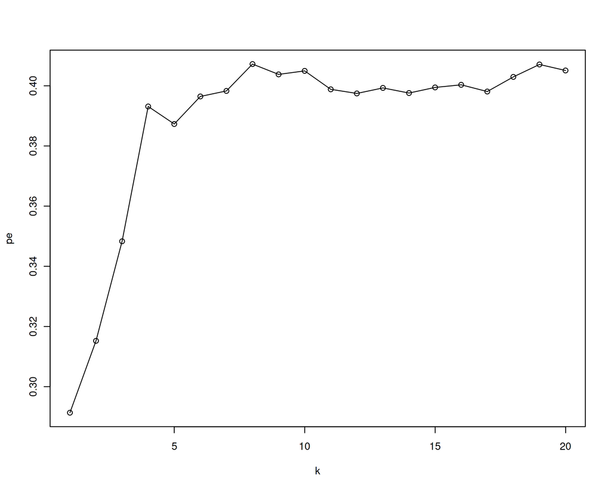

```r
n = nrow(airfoil2) # total number of observations
n2 = round(n * 0.10) # size of test set
K = 20 # largest K-value in comparison
R = 200 # number of repetitions
pe = matrix(nrow=R, ncol=K) # pre-allocate space for prediction errors

set.seed(769) # set a random seed
for(j in 1:K) {
  for(i in 1:R) {
    index = sample(n, n2)
    yhat = knn(train=X[-index,], test=X[index,], cl=airfoil2[-index,7], k=j) # prediction
    pe[i,j] = mean(yhat != airfoil2[index,7]) # misclassification rate for test data
}
}
# head(pe)
pe3 = colMeans(pe)
plot(1:K, pe3, type="o", xlab="k", ylab="pe")
```

```r
(k.optimal = which.min(pe3))
```

```
## [1] 1
```

6. Rewrite/reorganise your code so that each repetition can be carried out independently. Perform the Jackknifing selection of 𝐾(=1,2,…,20) using parallel computing, with function mclapply(). Compare the running times, with 1, 5, 10 or 20 cores used.

```r
n = nrow(airfoil2) # total number of observations
n2 = round(n * 0.10) # size of test set
K = 20 # largest K-value in comparison
R = 200 # number of repetitions

jackknife_knn_single <- function(k, n2, X, y) {
  pe = numeric(R)  # Vector to store prediction errors for each repetition
  index = sample(n, n2)  # Sample indices for test set
  yhat = knn(train = X[-index,], test = X[index,], cl = y[-index,7], k = k)  # Make predictions
  pe[i] = mean(yhat != y[index,7])  # Calculate misclassification rate
  return(mean(pe))  # Return average misclassification rate for this k
}

# Function to perform Jackknifing over multiple repetitions
jackknife_knn <- function(k, n2, X, y, R) {
  # Perform parallel computation for all repetitions
  pe = mclapply(1:R, function(i) jackknife_knn_single(k, n2, X, y), mc.cores = detectCores() - 1)
  return(mean(unlist(pe)))  # Return average misclassification rate for this k
}

# Set the number of cores for testing
core_counts <- c(1, 5, 10, 20)

# Initialize a list to store timing results
timing_results <- vector("list", length(core_counts))

# Measure execution time for different core counts
for (core_count in core_counts) {
  start_time <- Sys.time()

  # Perform parallel computation for all K values
  pe5 <- mclapply(1:K, function(k) jackknife_knn(k, n2, X, airfoil2, R), mc.cores = core_count)

  end_time <- Sys.time()
  elapsed_time <- end_time - start_time

  # Store results in the timing_results list
  timing_results[[as.character(core_count)]] <- list(time = elapsed_time, errors = unlist(pe5))
}
timing_results$'1'$time
```

```
## Time difference of 2.171037 secs
```

```r
timing_results$'5'$time
```

```
## Time difference of 1.31409 secs
```

```r
timing_results$'10'$time
```

```
## Time difference of 0.8627286 secs
```

```r
timing_results$'20'$time
```

```
## Time difference of 0.7211881 secs
```